#### Charging

[figure not shown]

##### How long does it take to charge on average?

*Source for level 1 and level 3 Charger info: http://www.mto.gov.on.ca/english/vehicles/electric/charging-electric-vehicle.shtml*

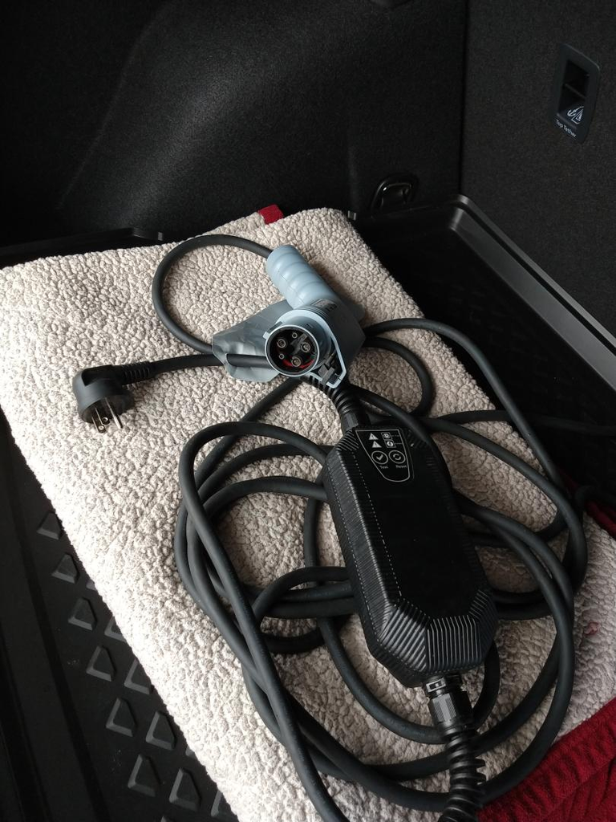

*A level 1 portable charging cord is included with the E-Golf.*

[figure not shown]

*A Flo Level 2 Charger installed at Medicine Hat College.*

[figure not shown]

*A Flo level 3 charger installed at Medicine Hat College.*

##### What are the options for home charging stations and how much do they cost?

The E-golf comes with a charger that is capable of level 1 charging from a 110V outlet.

Aftermarket charging stations from companies like Flo or ChargePoint are also available, which offer features such as faster charging than a wall outlet alone, longer charging cord, warranty and smartphone compatibility.

*Source: Owner’s Manual*

[figure not shown]

The Flo Home X5 level 2 charger allows for smartphone connectivity and can send usage data such as length of charge and power usage.

##### Which chargers are compatible with the e-golf?

The E-golf supports both SAE J1772 (J Plug) as well as CCS charger types, which allows the vehicle to be charged using level 1, 2 (J1772) and 3 (CCS) connectors.

[Plugshare](https://www.plugshare.com/) is a great web application that shows every charging station across the globe and allows filtering for plug designs, charging networks, payment requirements and more.

*Source: https://pulse.vwmodels.ca/2017/06/electric-vehicle-charging-101/*

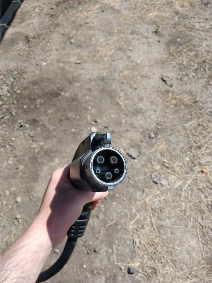

*The J1772 charger is used for charging the E-Golf with level 2 speed.*

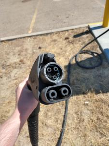

*The CCS charger is a variant of j1772 with additional pins to allow for level 3 charging of the E-golf.*

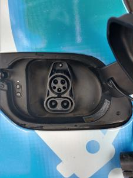

*The E-Golf charge port allows for both level 2 and level 3 charging.*

#### Consumer

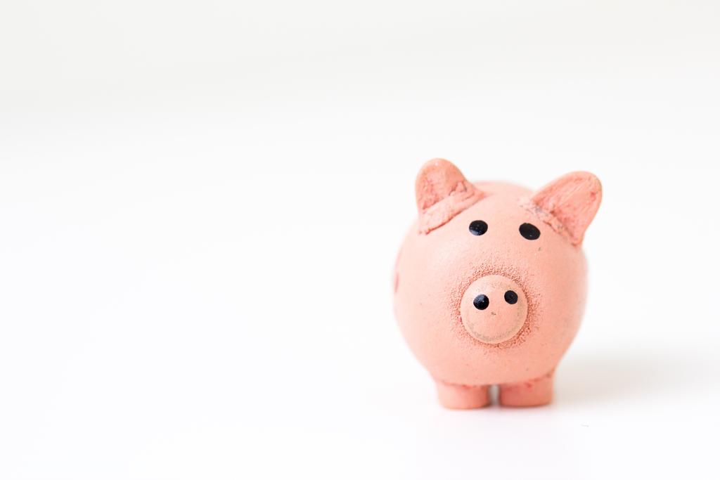

##### How much does an e-golf cost?

The MSRP of a 2019 Volkswagen E-golf is **$43,020**, plus the following fees and taxes:

- **Federal Air Conditioning:** $100.00
- **AMVIC fee:** $6.25
- **Tire tax:** $20.00 or $4.00/tire
- **Administration fee:** $599

The total price for an E-Golf is approximately **$43,745.25.**

*Source: Southland Volkswagen*

##### How much does it cost to charge the e-golf?

Using a rate of 12.8 cents/kWh and a battery capacity of 35.8kWh, it costs $4.58 for a full charge.

Public charging stations are often free, but some charge a flat rate or cost per kWh that is comparable to the cost of charging at home.

*Source for utility rate: Surveyed Medicine Hat residents for their utility rates.*

Source for battery capacity: https://ev-database.org/car/1087/Volkswagen-e-Golf

##### What maintenance do electric vehicles require?

Electric vehicles don’t require oil changes, fuel filter replacements, spark plug replacements or emission checks, but still will require regular maintenance of the brakes, tires, coolant and of course the battery.

##### What type of warranty does the e-golf have?

The warranty for the e-golf is as follows:

- Bumper to bumper coverage for **4 years** or **80,000 km**
- Powertrain limited warranty for **5 years** or **100,000 km**
- Corrosion Perforation warranty for **7 years, no kilometer limit**
- High voltage system warranty for **5 years** or **100,000 km**
- High voltage battery warranty for **8 years** or **160,000 km (net capacity loss below 70%)**

*Source: Canada Warranty and Maintenance booklet (For more information contact Southland Volkswagen)*

##### What type of Government incentives come with owning an electric vehicle?

As per the iZEV program, the Canadian Federal Government will award rebates for the following amounts (pertaining to the 2019 VW E-golf):

- $5,000 for full purchase
- $1,250 for a 12-month lease
- $2,500 for a 24-month lease
- $3,750 for a 36-month lease

*Source: https://www.tc.gc.ca/en/services/road/innovative-technologies/zero-emission-vehicles.html | Page last modified 08/14/2019*

[List of vehicles eligible for the iZEV program](https://www.tc.gc.ca/en/services/road/innovative-technologies/list-eligible-vehicles-under-izev-program.html).

##### How much does the e-golf cost to drive ($/km)?

(from a pure fuel persceptive)

#### Driving

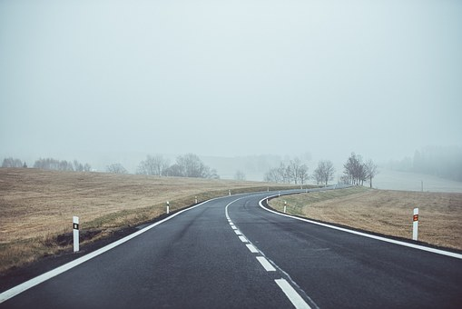

##### What is the averge range of the vehicle?

| Temperature (degrees C) | Range indicated at full charge (km) |
| --- | --- |
| -35.1 to -20 | 128 |
| -20 to -5 | 189 |
| -5 to 10 | 240 |
| 10 to 25 | 269 |
| 25 to 40.1 | 263 |

*Source: Data collected by MHC*

##### What is energy recuperation?

When the vehicle is braked or coasting (and not in energy recuperation level 0, different levels are discussed below), electrical energy is generated via the electric motor and stored in the high-voltage battery. This feature is called brake energy recuperation.

There are a total of 5 brake energy recuperation levels:

- **Level 0 (D0):** The vehicle can coast freely. energy is only recuperated whern pressing the brake pedal.
- **Level 1 (D1):** Light brake energy recuperation.
- **Level 2 (D2):** Medium brake energy recuperation.
- **Level 3 (D3):** High brake energy recuperation.
- **Level 5 (B):** Very high brake energy recuperation.

*Source: Owner’s Manual*

##### How fast is the e-golf?

Relevant specs of the e-golf are as follows:

*Source: https://ev-database.org/car/1087/Volkswagen-e-Golf*

##### What are the drive modes?

The drive modes change the way the e-golf consumes power:

**Eco:** Energy consumption is reduced compared to the Normal driving mode. The power of the electric motor is reduced compared to the normal driving mode. Climatronic<sup>1</sup> heating and cooling is optimized for consumption. Maximum speed is reduced to 120km/h.

**Eco-Plus:** The power of the electric motor is reduced beyond that of Eco mode. Climatronic<sup>1</sup> heating and cooling is disabled, but defrost and ventilation are still available. Maximum speed is reduced to 95 km/h.

*Source: Owner’s Manual*

*1. Climatronic refers to the vehicle’s automatic climate control function, which allows the internal temperature to be set at a certain degree value.*

##### How does temperature affect the range of the e-golf?

According to our data (shown above), the predicted range of the e-golf increases as temperature increases.

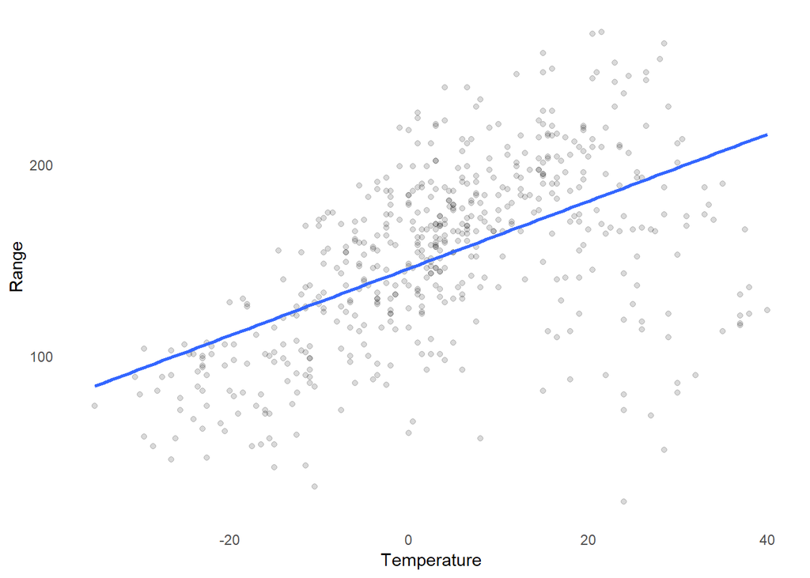

*Source: Data collected by MHC*

##### What is blue score and the Think Blue Trainer?

The Think Blue trainer analyzes your driving and utilizes a visual display to help you adopt a more energy efficient driving style. Blue score is the metric used to rate the efficiency of your driving style.

*Source: Owner’s Manual*

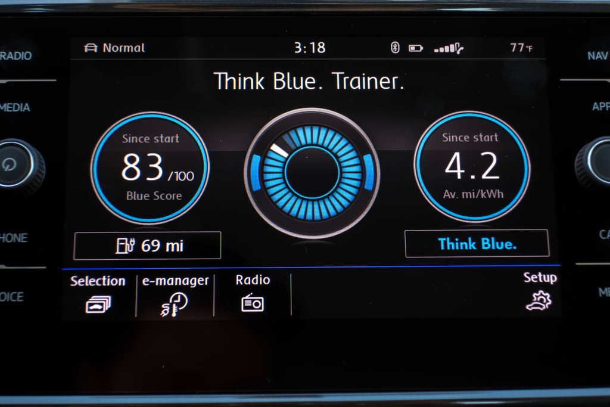

*The main screen of the Think Blue Trainer. Each blue segment in the middle circle represents a 5 second interval of driving. The size of the segment relates to the blue scored awarded during that interval. *Photo Source: https://www.cars.com/articles/2017-volkswagen-e-golf-review-quick-spin-1420695411332/**

#### Driver Feedback

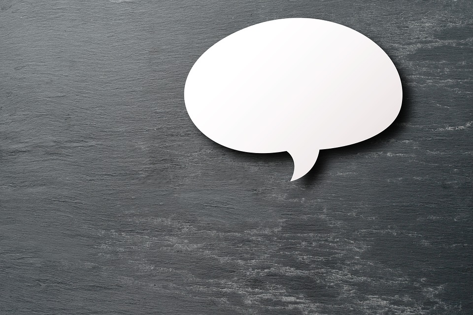

##### How does the car feel to drive?

**Driver 1:** The car is very nice with all available torque at take-off. I loved the departure feature in the winter, getting into a warm and defrosted car ready to go while plugged in was great. The car handled great with all of the weight so close to the ground and evenly distributed, The heating and air conditioning was very quick and kept the cabin feeling great. I really enjoyed the experience of driving the car.

**Driver 2:** Smooth, quiet, fast, and fun!

**Driver 3:** So quiet, and so smooth to drive! I loved it.

**Driver 6:** Good, was smooth and felt clean and less bulky than my gas vehicle. There were a few times when it didn’t start fully which were confusing, but otherwise it was awesome.

**Driver 7:** It was super fun to drive, it felt like a go-kart. Plenty of acceleration, good handling, stable on the highway. It was easier to drive than my car, just push the pedal and zoom zoom! All the little features like lane assist and auto-park were neat, but not much more than a gimmick in my experience.

##### Did you feel the car was convenient to drive? Why or why not?

**Driver 1:** Yes, it was very convenient to drive, the actual driving of the car varied greatly because the amount you have to brake can be greatly reduced by the state of battery and how much regeneration you have selected.

**Driver 3:** Yes, although data collection was a bit of work :P.

**Driver 6:** Yes, it did everything I needed it to do.

**Driver 7:** Charging was interesting - I found that once I started charging it nightly, like my phone, I stopped worrying about range anxiety.

##### Was the infotainment system intuitive to use? Why or why not?

**Driver 1:**Yes, it was easy to use and collect valid data off of.

**Driver 2:** I only used it for the necessary data gathering so my opinion may be vague, but it seemed ok!

**Driver 3:** Mostly yes, a couple things required searching for but it was overall easy to use.

**Driver 6:** For the most part. Sometimes if I accidentally went to the main screen it took me awhile to get back to the data screen. There are a lot of options on the main screen which are cumbersome to figure out if your attention is divided.

**Driver 7:** Sure, my car doesnt have anything like it to compare to - but I was able to connect my phone and make calls/listen to music without an issue.

##### How likely are you to buy an electric vehicle in the next 5 years?

**Driver 1:** I most likely will not be purchasing an electric vehicle in the next five years because I just updated and they last me longer than that. I am however looking forward to the next upgrade, it will most likely be electric or have an electrified component to it (PHEV).

**Driver 2:**I would for sure. In that time we’ll have longer range and more charging options.

**Driver 3:** Extremely likely. It would save tons of money on gas! Even brand new, the price is similar to other gas models. For example, a brand new Ford Flex is also around $50,000.

**Driver 6:** I’d like to, but need the range to increase a lot before it would work well for my lifestyle. I also need to do more research (or have it made readily available by VW?) on the batteries - warranty, lifespan, how environmentally damaging this battery is compared to conventional batteries in terms of mining, disposal etc. I just don’t know enough yet.

**Driver 7:** Pretty unlikely, simply because my car still has a lot of miles left to go on it. When the time comes to buy something, I’ll definitely look at whats available.

##### What was your favorite part about driving the car?

**Driver 1:** I never had to worry about it running out of fuel with the trips I was taking when it was fully charged in the morning.

**Driver 2:** Inexpensive and quiet.

**Driver 3:** It’s really fast! Almost got a few speeding tickets.. :P

**Driver 6:** Flooring it, for sure!

**Driver 7:** Taking my dad for a drive and showing him how quiet it is!